# Coursework Report

*N* removed NAs: 3

*N* removed typo: 1

*N* removed <18: 35

*N* total clean: 111

| Group | *N* | *M*<sub>age</sub> | *M*<sub>rating</sub> |
| --- | --- | --- | --- |
| Control | 53 | 21.09 | 6.23 |
| Experim | 58 | 20.40 | 5.37 |

**Main analysis results**

*t*(109) = 5.27, *p* < .001

[interactive chart not shown]

[figure not shown]

[interactive chart not shown]

# Coursework Report

Analysing Data, Spring 2020

# Methods

## Participants

Data from 111 participants (*M*<sub>age</sub> = 20.73 *SD*<sub>age</sub> = 2.3) was collected. This excludes data from 36 participants who were too young or were an unlikely age. Further, 3 participants did not disclose their age and were therefore excluded. Table 1 shows the distribution of age by condition.

## Design

The research questions this study assessed was, ‘does colour influence attractiveness?’. The participants saw a picture of a man with either a red frame (experimental group) or a white frame (control group) and then rated the man’s attractiveness. The colour of the frame was an independent categorical variable and the measure of attractiveness was a continuous variable. Attractiveness was assessed with three questions: ‘how attractive do you think this person is?’, ‘how pleasant is this person to look at?’, and ‘if I were to meet the person in this picture face to face, I would think he is attractive’. The questions were rated on a 9-point-scale from 1 (not attractive at all) to 9 (extremely attractive) and the three scores were averaged to create a composite score. The hypothesis is that viewing a red coloured frame around an image of a moderately attractive man will lead to higher mean attractiveness rating than the same image in a white coloured frame. A two-tailed t-test will be used to determine if there is any significant difference between the means of the experimental group and the control group.

Table 1 *Descriptive Statistics of Age by Condition*

| GROUP | mean_age | sd_age | min_age | max_age |
| --- | --- | --- | --- | --- |
| control | 21.09 | 2.30 | 18 | 27 |
| experimental | 20.40 | 2.28 | 18 | 28 |

# Results

We wanted to know whether there was a relationship between the colour of a border around an image of a moderately attractive male and perceived attractiveness. We therefore conducted a two-tailed t-test comparing the means of the control and experimental groups perceived attractiveness. This model indicated that there was a significant difference in mean attractiveness rating for the red vs white conditions (*M*<sub>diff</sub> = -0.86, 95% CI [0.54, 1.19], *t*(109 = 5.27), *p*<.001). This means that, contrary to the hypothesis, the control group had a higher average rating of attractiveness compared to the experimental group (6.23, 5.37) shown in the graph below.

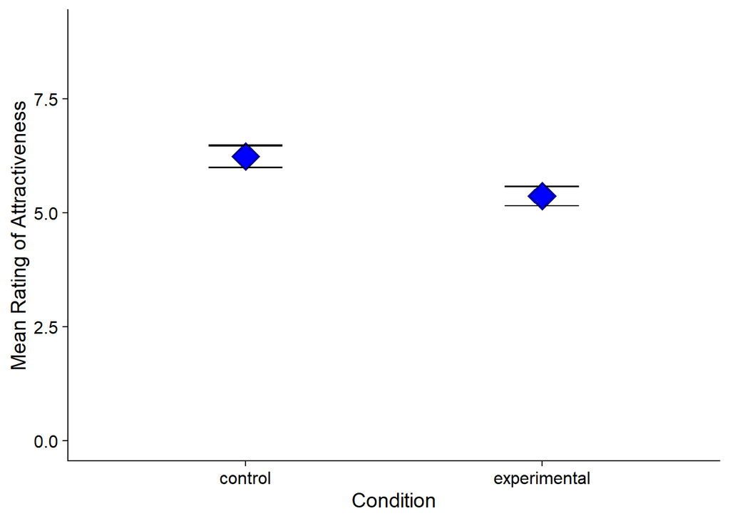

# Discussion

This research set out to answer the question, does colour influence attractiveness? The current research was successful in testing the hypothesis however the hypothesis was not supported by the results. Contrary to our hypothesis, it was found that viewing a picture of a moderately attractive man in a white coloured frame led to a higher mean attractiveness rating compared to when the same picture was viewed in a red coloured frame. The original study (Elliot et al., 2010) found that participants in the red condition rated the target man as more attractive compared to those in the white condition. These findings do not compare with what was found in the current research. Other research has also struggled to find a ‘red effect’ when considering attractiveness. Hesslinger, Goldbach, & Carbon (2015) also replicated Elliot’s (2010) study and found no significant impact of the colour red on attractiveness. Peperkoorn, Roberts & Pollet (2016) found similar results. However, Young (2015) found that the colour red increased men’s ratings of female attractiveness but only for faces that were pre-rated as attractive and had no effect on ratings on initially unattractive faces. The red effect has found to influence other aspects of research, for example, Fortier-Gauthier, Acqua, & Joliceur (2013) conducted a study where participants had to state the orientation of a segment inside a circle that was coloured either red or green. They found that participants had quicker reactions when the circle was red compared to when it was green. However, Smajic, Merritt, Banister & Blinbry (2014) found no significant effect of the colour red on performance in an exam. As can be seen, many studies have failed to find a ‘red effect’ and the current study is in line with suggesting that a ‘red effect’ does not exist. The current findings also open up a possibility that the colour white may have more of an influence on perceived attractiveness.

Several other studies that have explored the red effect used green as the opposing colour which may be why the results were different and the higher attractiveness ratings with the colour white were not found. Future research could measure more than just two colours (e.g. red, green and white) and see what the attractiveness ratings are. One possible reason for the white group having higher attractiveness ratings is that the colour white, in western cultures, is often associated with weddings, peacefulness, cleanliness, and purity (Cherry, 2020). If the participants associated these traits with the man in the picture, if may have lead them to rate him as more attractive.

One limitation is the study was conducted on students only and to make the results more generalizable to the real world, the study should be conducted on a wider range of participants. A further weakness is that measurements of what participants initially find attractive were not taken. It may also be important to add some questions about what the participants find attractive in a man as differences in results may be caused due to differences in what the participants finds attractive (e.g. the participant may have rated the participant low on attractiveness simply because they did not find them attractive, not because of the colour). The ‘red effect’ may be true in other areas or self-perceived attractiveness (Berthold, Reese, & Martin, 2017) but the evidence does not seem to support there being a ‘red effect for other rated attractiveness. One area for future research would be to test the red effect and also to test whether the colour white influences attractiveness ratings. An experiment similar to the current research should be conducted but also test a wider range of people including a variety of ages and also straight men, straight women, gay men and lesbian women to test whether there is an effect of colour on perceived attractiveness in all groups of people. It would also be beneficial to use multiple colours such as red, white and green to see which colour, if any, have the strongest influence over attractiveness ratings.

No evidence of a ‘red effect’ on attractiveness was found in this research and an opposite ‘white effect’ was found to make attractiveness ratings higher. There is not enough evidence in research to suggest that there is a red effect on attractiveness, however, future, more in-depth research should examine further the effects colours can have on attractiveness ratings.

# References

Berthold, A., Reese, G., & Martin, J. (2017). The effect of red color on perceived self-attractiveness: Red color and self-attractiveness. European Journal of Social Psychology, 47(5).

Cherry, K. (2020). The color psychology of white. Retrieved from: https://www.verywellmind.com/color-psychology-white-2795822

Elliot, A.J., Kayser, D.N., Greitemeyer, T., Lichtenfeld, S., Gramzow, R.H., Maier, M.A., & Liu, H. (2010). Journal of Experimental Psychology, 139(3), 399-417.

Fortier-Gauthier, U., Acqua, R.S., & Joliceur, P. (2013). The “red-alert” effect in visual search: Evidence from human electrophysiology. Psychophysiology, 50, 671-679.

Hesslinger, V.M., Goldbach, L., & Carbon, C.C. (2015). Men in red: A re-examination of the red-attractiveness effect. Psychonomic Bulletin & Review, 22, 1142-1148.

Peperkoorn, L.S., Roberts, S.C., & Pollet, T.V. (2016). Revisiting the red effect on attractiveness and sexual receptivity: No effect of the color red on human mate preferences. Evolutionary Psychology, 14(4), 1-13.

Smajic, A., Merritt, S., Banister, C., & Blinebry, A. (2014). The red effect, anxiety and exam performance: A multistudy examination. Teaching of Psychology, 4(1), 37-43.

Young, S.G. (2015). The effect of red on male perceptions of female attractiveness: Moderation by baseline attractiveness of female faces. European Journal of Social Psychology, 45, 146-151.